# Michael Barrowman, MSci

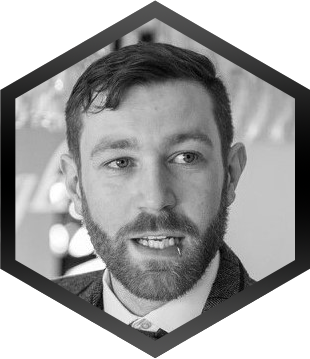

: (+44) 07467 456 803

: myko101ab@gmail.com

: [@MyKo101ab](https://twitter.com/MyKo101ab)

: MyKo101

: 0000-0003-0718-4482

: [michael-barrowman](https://www.linkedin.com/in/michael-barrowman-0403a960/)

: [Newton-Le-Willows](https://www.google.com/maps/place/Newton-le-Willows/@53.4584287,-2.6730042)

: Download PDF CV

## Bio

### About Me

Expert data scientist with a Masters Degree in Mathematics, approaching completion of a PhD in Medicine with a focus on Statistics. Achievements include 10% improvement in effective productivity in examination marking, the creation of SAPs and SOPs for a pioneering pragmatic clinical trial and the development and validation of a multi-state clinical predication model, as well as the methodological advancements to produce such a model. I have a multitude of published works including packages in R, where my most recent experience lies, articles in high impact journals covering methodology and clinical advances. Highly skilled in data processing, visualisation and model building. Extremely versatile in language use and flexible in it’s application.

### Skills

[figure not shown]

[figure not shown]

RMarkdown —

[figure not shown]

LaTeX —

[figure not shown]

SPSS —

[figure not shown]

NVivo —

[figure not shown]

Git —

[figure not shown]

GitHub —

[figure not shown]

GitHub Actions —

[figure not shown]

HTML/CSS —

[figure not shown]

Regex —

[figure not shown]

Python —

[figure not shown]

SAS —

[figure not shown]

Stata —

[figure not shown]

SQL —

[figure not shown]

Microsoft Office —

[figure not shown]

Google Suite —

[figure not shown]

Photoshop

## Experience

[output not shown]

## Software

[figure not shown]

**typos** (R Package)  
The goal of typos is to provide a flexible warning when commonly mis-typed functions are called. Functions with typing errors will still be evaluated and a warning will be output. It also provides the user with a convenient function to define their own typos.

**mutils** (R Package)  
The goal of mutils is to provide useful functions to make data processing smoother. Most functions contained here are “nifty”, rather than “innovative”.

[figure not shown]

[figure not shown]

**mpipe** (R Package)  
The mpipe package is designed to add extra functionality to the pipeline process in tidyverse style R usage

## Publications

[output not shown]

Online & Downloadable CV Produced by Michael Barrowman via RMarkdown: [Source](https://github.com/MyKo101/CV)